# Juvenile Snowshoe Hares: exploratory report

Alyssa Kibbe

# Exoloration of Snowshoe Hares

## 1. Introduction :

This report explores the relationship between juvenile snowshoe hare size at three testing locations in the Tanana Valley from 1999 to 2012 (Kiellan et al. 2017). Juvenile hare weights is compared between males and females at each of the testing sites. In addition, juvenile hare weight was compared to hind foot length. All relationships in this report focus on the juvenile hares from the larger data set.

## 2. Data and analyses:

The data was collected by Knut Kielland and their team in the Tanana valley in Alaska. The data measures quantitative characteristics of the snowshow hares observed at each field site. Experimental variables include, weight, hind foot length, age, sex, and unique identifiers. Analyses used in the report include graphical representations of relationships, t-tests for variance, and correlation tests. T-tests were conducted to find the relationship between the sex and weight of the juvenile hare. Cohen’s d test was used to calculate the effect size. The relationship between weight and hind foot length was observed by creating a linear regression model. RStudio version 1.3.1073 was used to complete all analyses.

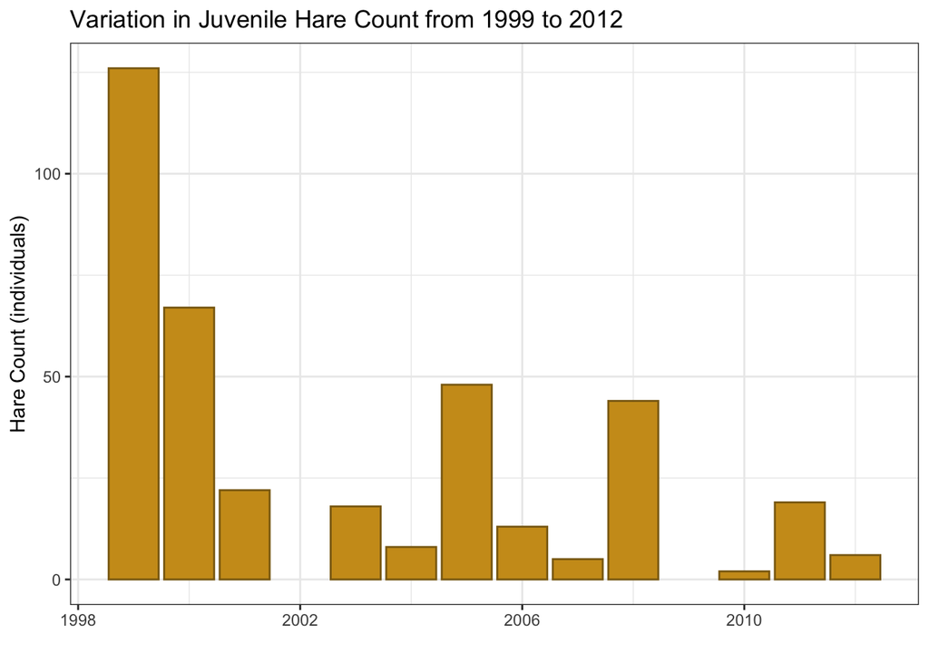

There is large variation in the snowshoe hare populations (min = 2 (2010), max = 126 (1999))(Figure 1). The overall trend of the data is skewed to the right. The number of observed snowshoe hares varies in each collection year (mean = 31 indiv. median = 18.5 indiv.). There are inconsistencies in the data that may have influences the results. In 2000, data was collected on 11 different days while in 2012, data was only collected on 2 days. For future collections, it would be beneficial to have a consistent number of sampling days each year.

## 3. Results

### A. Exploring the relationship between sex and juvenile weight

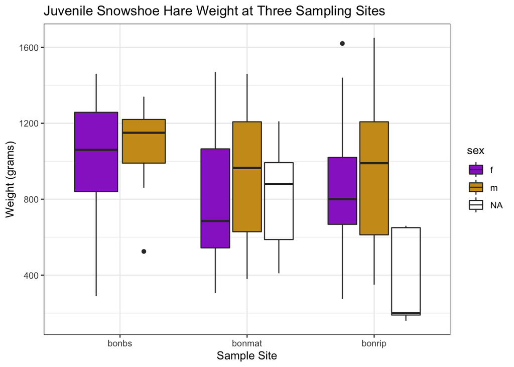

##### **Figure 2: Variation in weight (grams) between males and females at three sampling sites (bonbs, bonmat, bonrip).** “bonbs” is the sampling site consisting of lowland black spruce, “bonmat” or Bonanza Mature is a forested area filled with mature tree species. “bonrip” or Bonanza Riparian is the flood zone from the Tanana River. NA represents individuals with unidentified sex. Bars represent median values, box end points depict 25th and 75th percentile. Points show outliers. Data: Kielland et al. (2017).

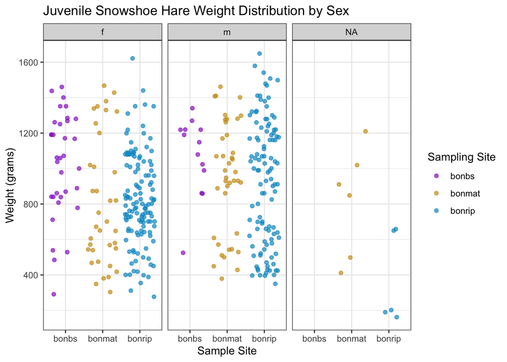

##### **Figure 3: Weight (grams) distribution of males and females at three sampling sites.** “bonbs” is the sampling site consisting of lowland black spruce, “bonmat” or Bonanza Mature is a forested area filled with mature tree species. “bonrip” or Bonanza Riparian is the flood zone from the Tanana River.NA represents individuals with unidentified sex. Data: Kielland et al. (2017).

Juvenile male hares have an greater average weight than females (Figure 2). In addition, the weights across the three locations show similar trends. However, there is the greatest difference in average weight in the Bonanza Mature sample population. The Bonanaza Riparian zone has the greatest number of sample points and thus has that largest variation in hare weights. The variation in the recorded weights of males and females at each site (Figure 3).

##### Table 1: **Summary stastics for juvenile snowshoe hares.** NA values for weight for a specific sex were excluded. NA values in table represent individual hares with unknown sex. Data: Kielland et al. (2017).

| sex | mean_weight | sd_weight | sample_size |
| --- | --- | --- | --- |
| f | 855.3909 | 292.2526 | 200 |
| m | 945.8589 | 333.2151 | 163 |
| NA | 614.5455 | 357.5853 | 15 |

The actual difference in male and female average weight is 90.468 grams (10.05% difference). The difference in means is significant (Welch’s two-sample t-test: t(325) = 2.71, p = 0.007) and the effect size is small (Cohen’s d = 0.290). This means that there is a 0.7% chance of taking random samples from populations with the same mean and finding sample means as different as those found here.

### B. Exploring the relationship between juvenile weight and hind foot length

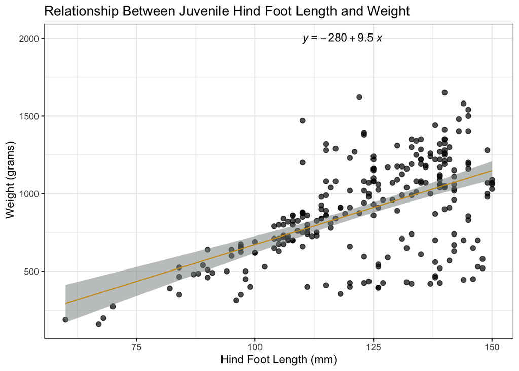

## Next steps:

- Conduct similar tests with adult snowshoe hares and see if similar trends appear
- Compare weights and hind foot length between adults and juveniles

##### Citation : Kielland, K., F.S. Chapin, R.W. Ruess, and Bonanza Creek LTER. 2017. Snowshoe hare physical data in Bonanza Creek Experimental Forest: 1999-Present ver 22. Environmental Data Initiative. https://doi.org/10.6073/pasta/03dce4856d79b91557d8e6ce2cbcdc14